# MEDL_HW10_Soln

**Deep Learning for Mechanical Engineering**  
**Homework 10 Solution**  
**Due Thursday, 06/23/2020, 3:30 PM**

TA: Kangsan Lee and Namjeong Lee  
Instructor: Prof. Seungchul Lee  
http://iai.postech.ac.kr/  
Industrial AI Lab at POSTECH

- For your handwritten solution, scan or take a picture of them.
- For your code, only .ipynb file will be graded.
  - Please write your NAME and student ID on your .ipynb files. ex) KangsanLee_20202467_HW09.ipynb
- Please compress all the files to make a single .zip file
  - Please write your NAME and student ID on your .zip files. ex) NamjeongLee_20202467_HW09.zip
  - Submit it to LMS
- Do not submit a printed version of your code. It will not be graded.

# Problem 1:

By the GAN algorithm, we can even change the style of images. In this problem, we will change the white-colored digit in a black background image to the black-colored digit in a white background image.

We will use the following GAN structure.

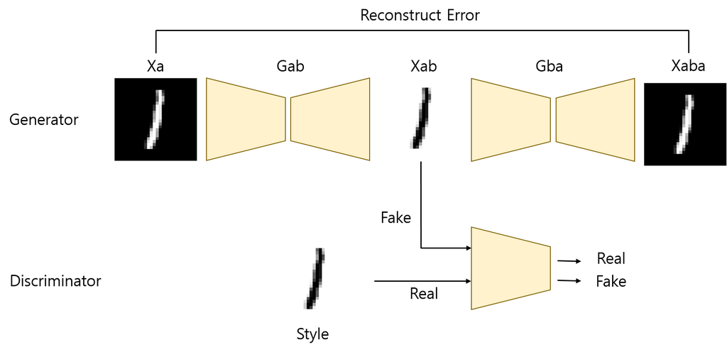

Download data from [here](https://www.dropbox.com/s/brtswyczsk3bwzy/one.pkl?dl=1)

**Description**

- Domain A: white-colored number in a black background
- Domain B: black-colored number in a white background
- Generate Xab image by generator Gab
  - the structure of Gab is like an autoencoder
- Generate Xaba image by generator Gba
  - the structure of Gba is like an autoencoder
- Train the style to Gab generate styled image Xab
  - give reconstructed Xab image as a fake image and style image as a real image to the discriminator.

Note: I strongly recommend you to use either GPU or Colab. Don't use CPU to train your model! It will take a long time to complete training.

```python
import numpy as np
import matplotlib.pyplot as plt
from six.moves import cPickle
import tensorflow as tf
```

(1) Load data. Then make color images inveted and plot one of them.

- one.pkl
  - white-colored number in a black background image

```python
one = cPickle.load(open('./data_files/one.pkl', 'rb'))
```

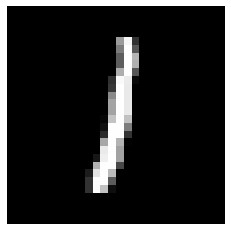

```python
plt.imshow(one[0].reshape(28,28), 'gray')
plt.axis('off')
plt.xticks([])
plt.yticks([])
plt.show()
```

```python
bnum = np.abs(1-one)
```

```python
wnum = one
```

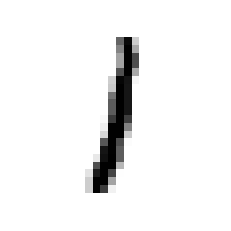

```python
plt.imshow(bnum[0].reshape(28,28), 'gray')
plt.axis('off')
plt.xticks([])
plt.yticks([])
plt.show()
```

```python
train_bnum = bnum[:np.int(len(bnum)*0.7)]
test_bnum = bnum[np.int(len(bnum)*0.7):]

train_wnum = wnum[:np.int(len(wnum)*0.7)]
test_wnum = wnum[np.int(len(wnum)*0.7):]
```

(2) Define your model.

- Generator AB
  - `n_G_input`: 28 $\times$ 28
  - `n_G_encoder1`: 256
  - `n_G_latent1`: 50
  - `n_G_decoder1`: 256
- Generator BA
  - `n_G_encoder2`: 256
  - `n_G_latent2`: 50
  - `n_G_decoder2`: 256
- Discriminator
  - `n_D_input`: 28 $\times$ 28
  - `n_D_hidden`: 256
  - `n_D_output`: 2

```python
### Generator
## G_ab
# Shape of input and latent variable
n_G_input = 28*28
# Encoder structure
n_G_encoder1 = 256
n_G_latent1 = 50
# Decoder structure
n_G_decoder1 = 256

## G_ba
# Encoder structure
n_G_encoder2 = 256
n_G_latent2 = 50
# Decoder structure
n_G_decoder2 = 256

### Discriminator
n_D_input = 28*28
n_D_output = 2
n_D_hidden = 256
```

```python
weights = {
    'Gab_en' : tf.Variable(tf.random_normal([n_G_input, n_G_encoder1], stddev = 0.1)),
    'Gab_la' : tf.Variable(tf.random_normal([n_G_encoder1, n_G_latent1], stddev = 0.1)),
    'Gab_de' : tf.Variable(tf.random_normal([n_G_latent1,n_G_decoder1], stddev = 0.1)),
    'Gab_re' : tf.Variable(tf.random_normal([n_G_decoder1, n_G_input], stddev = 0.1)),

    'Gba_en' : tf.Variable(tf.random_normal([n_G_input, n_G_encoder2], stddev = 0.1)),
    'Gba_la' : tf.Variable(tf.random_normal([n_G_encoder2, n_G_latent2], stddev = 0.1)),
    'Gba_de' : tf.Variable(tf.random_normal([n_G_latent2, n_G_decoder2], stddev = 0.1)),
    'Gba_re' : tf.Variable(tf.random_normal([n_G_decoder2, n_G_input], stddev = 0.1)),

    'D1' : tf.Variable(tf.random_normal([n_D_input, n_D_hidden], stddev = 0.1)),
    'D2' : tf.Variable(tf.random_normal([n_D_hidden, n_D_output], stddev = 0.1))
    }

biases = {
    'Gab_en' : tf.Variable(tf.random_normal([n_G_encoder1], stddev = 0.1)),
    'Gab_la' : tf.Variable(tf.random_normal([n_G_latent1], stddev = 0.1)),
    'Gab_de' : tf.Variable(tf.random_normal([n_G_decoder1], stddev = 0.1)),
    'Gab_re' : tf.Variable(tf.random_normal([n_G_input], stddev = 0.1)),

    'Gba_en' : tf.Variable(tf.random_normal([n_G_encoder2], stddev = 0.1)),
    'Gba_la' : tf.Variable(tf.random_normal([n_G_latent2], stddev = 0.1)),
    'Gba_de' : tf.Variable(tf.random_normal([n_G_decoder2], stddev = 0.1)),
    'Gba_re' : tf.Variable(tf.random_normal([n_G_input], stddev = 0.1)),

    'D1' : tf.Variable(tf.random_normal([n_D_hidden], stddev = 0.1)),
    'D2' : tf.Variable(tf.random_normal([n_D_output], stddev = 0.1))
}
```

```python
z= tf.placeholder(tf.float32, [None, n_G_input])
# z2 = tf.placeholder(tf.float32, [None, n_G_input])
x = tf.placeholder(tf.float32, [None, n_D_input])
```

```python
def Gab(G_input, weights, biases):
    # Gab
    Gab_encoder = tf.nn.relu(tf.matmul(G_input, weights['Gab_en']) + biases['Gab_en'])
    Gab_latent = tf.nn.relu(tf.matmul(Gab_encoder, weights['Gab_la']) + biases['Gab_la'])
    Gab_decoder = tf.nn.relu(tf.matmul(Gab_latent, weights['Gab_de']) + biases['Gab_de'])
    Gab_reconst = tf.nn.sigmoid(tf.matmul(Gab_decoder, weights['Gab_re']) + biases['Gab_re'])

    return Gab_reconst

def Gba(Gab_reconst, weights, biases):
    # Gba
    Gba_encoder = tf.nn.relu(tf.matmul(Gab_reconst, weights['Gba_en']) + biases['Gba_en'])
    Gba_latent = tf.nn.relu(tf.matmul(Gba_encoder, weights['Gba_la']) + biases['Gba_la'])
    Gba_decoder = tf.nn.relu(tf.matmul(Gba_latent, weights['Gba_de']) + biases['Gba_de'])
    Gba_reconst = tf.nn.sigmoid(tf.matmul(Gba_decoder, weights['Gba_re']) + biases['Gba_re'])

    return Gba_reconst
```

```python
def discriminator(D_input, weights, biases):
    hidden = tf.nn.relu(tf.matmul(D_input, weights['D1']) + biases['D1'])
    output = tf.nn.sigmoid(tf.matmul(hidden, weights['D2']) + biases['D2'])
    return output
```

(3) Define batchmaker to pick random Xa and style images.

```python
def batchmaker(n_batch):
    idx = np.random.randint(len(train_wnum), size = n_batch)
    Xa  = train_wnum[idx]
    style = train_bnum[idx]
    return Xa, style
```

(4) Define loss and an optimizer.